# Brazilian Vaccine Data

Paul Truche

11/16/2020

In this study, we examine how the number of vaccines adminstered in Brazil has changed as a result of the COVID19 pandemic.

Our data comes from DATASUS which tabulates the number of vaccines distributed by state for each month. Here we utilize data from 2015 thorugh 2020. Annual population estimates were obtained for 2015 thorugh 2020 through IBGE.

Here we can see the total number of vaccinations nationally over time

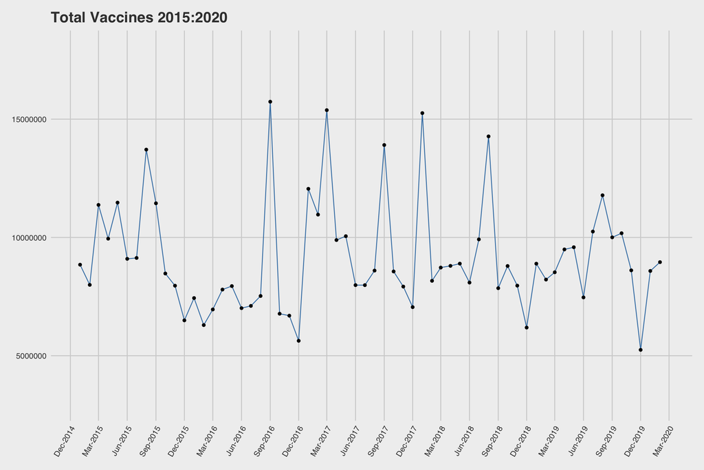

We can compare the raw number of vaccinations across states

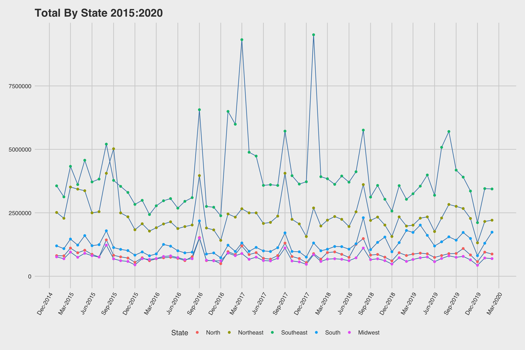

In order to identify potential temporal outliers, we utlize control charts in order to study how the number of vaccines changes over time. We utilize the rate of vaccine adminstration per 1000 persons.

Here we use an I chart followed by a moving range (MR) chart. This chart does not take into account potential differences across states and usually the national aggregaetes only.

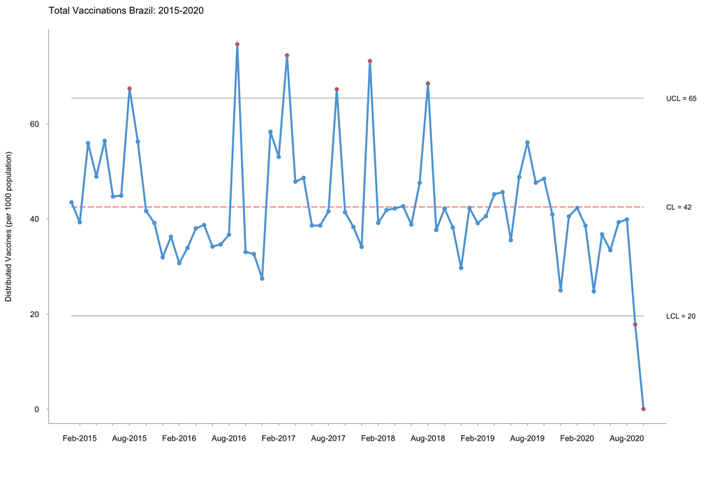

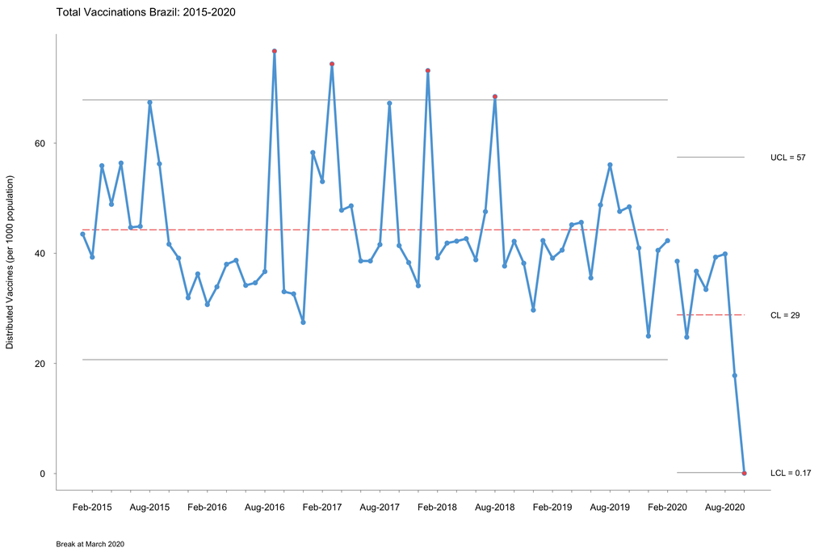

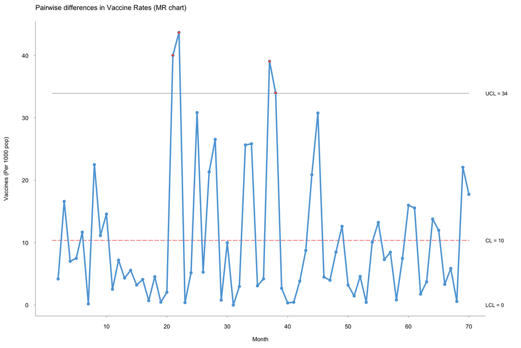

Below we use an xbar chart in order to incorperate vaccine rates per 1000 people by state.

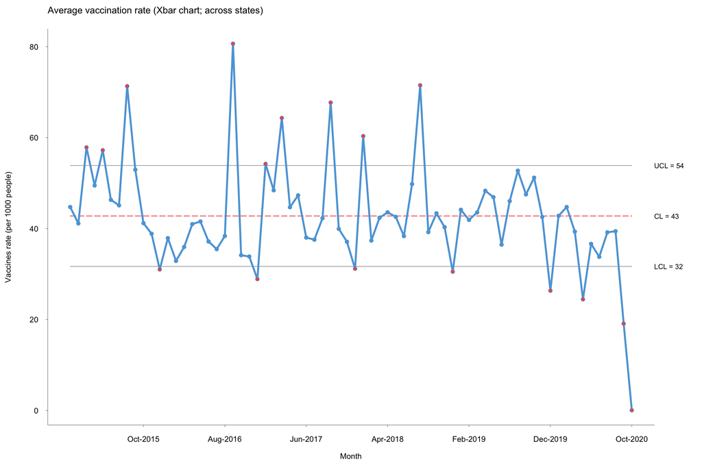

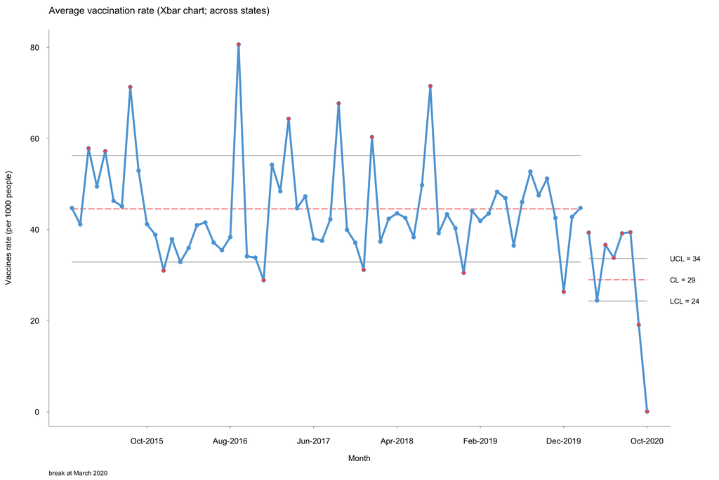